# Generative models of rotor speed and rotor noise

The fitted trajectory model, the fitted noise model, and what they transfer

Dmitrii Mukhutdinov

2026-09-22

## Trajectory model

$$\begin{aligned}
w(t) &= \mu + \delta_{\text{flight}} + M\,R(\theta)\,v(t) + e(t) \\
v_i(t) &= \mathrm{OU}(\tau_{\mathrm{slow},i}, \sigma_{\mathrm{slow},i}) + \mathrm{CAR2}(f_{0,i}, \zeta_i, \sigma_{\mathrm{osc},i}) \\
e_j(t) &= \mathrm{OU}(\tau_e, \sigma_e), \quad \text{independent across rotors} \\
\delta_{\text{flight}} &= \mathbf{1}c + r, \quad c \sim N(0, s_c^2),\; r \sim N(0, \operatorname{diag}(s_r^2)) \\
\mathrm{CAR2}&: \; \ddot{x} + 2\zeta\omega_0\dot{x} + \omega_0^2 x = \xi, \quad \omega_0 = 2\pi f_0
\end{aligned}$$

$M$ = mixer, columns $[\text{common}, \text{roll}, \text{pitch}, \text{yaw}]$; $R(\theta)$ rotates the (common, yaw) plane. $S(\omega) = \tfrac{2}{f_s} H (e^{i\omega}I - \Phi)^{-1} Q (e^{-i\omega}I - \Phi^\top)^{-1} H^\top$, $\Phi = e^{A\Delta t}$, $Q = P - \Phi P \Phi^\top$.

## Trajectory model — parameters

| symbol | meaning | shape | range / prior |
| --- | --- | --- | --- |
| $\mu$ | per-rotor hover level (rev/s) | 4 | estimated from airborne samples |
| $\theta$ | rotation of the (collective, yaw) plane (rad) | 1 | $(-\pi/4, \pi/4]$ canonical |
| $\tau_{\mathrm{slow}}$ | slow OU time constant per mode (s) | 4 | $(\tau_c, 10]$, LN(2.0 s, 1.5) |
| $\sigma_{\mathrm{slow}}$ | slow OU stationary sd per mode (rev/s) | 4 | LN(1.0, 3.0) |
| $f_0$ | oscillator centre frequency per mode (Hz) | 4 | $(0.05, 20)$ |
| $\zeta$ | oscillator damping ratio per mode | 4 | $(0.2, 3.0)$ |
| $\sigma_{\mathrm{osc}}$ | oscillator stationary sd per mode (rev/s) | 4 | LN(1.0, 3.0) |
| $\tau_e$ | measurement OU time constant (s) | 1 | $(10^{-3}, 1)$, LN(0.05 s, 2.0) |
| $\sigma_e$ | measurement OU sd, per rotor (rev/s) | 1 | LN(0.1, 3.0) |
| $s_c$ | sd of the per-flight level common to the rotors (rev/s) | 1 | moment estimate |
| $s_r$ | sd of the per-flight per-rotor level (rev/s) | 4 | moment estimate |

32 parameters; 23 enter the exact Kalman likelihood. $\tau_c = 1/(2\pi f_0)$.

## Trajectory data

| rig | vehicle | flights | airborne (s) | native rate | speed source |
| --- | --- | --- | --- | --- | --- |
| `michaels` | DJI Matrice 100 | 4 | 395 | 29.41 Hz | DatCon ESC feedback |
| `dregon` | MikroKopter quad | 10 | 429 | ~1 kHz grid | `motor.measured` |
| `neurobem_quad` | custom quad | 247 | 2479 | 400 Hz | Betaflight ESC feedback |
| `pitcn_quad` | micro quad, 0.25 kg | 68 | 3345 | 100 Hz | ESC telemetry |
| `nanobench_cf21b` | Crazyflie 2.1 Brushless | 15 | 668 | 100 Hz | bidirectional DSHOT eRPM |
| `vid_m100` | DJI M100 derivative | 4 | 397 | ~1 kHz CAN | M3508/C620 CAN feedback |
| `blackbird_quad` | custom quad | 1 | 199 | 187 Hz | optical motor encoders |
| **total** |  | **349** | **7912** |  |  |

Hover level 78–278 rev/s; per-rotor variance spans a factor of 600. Common analysis grid 100 Hz.

## Real vs sampled trajectories

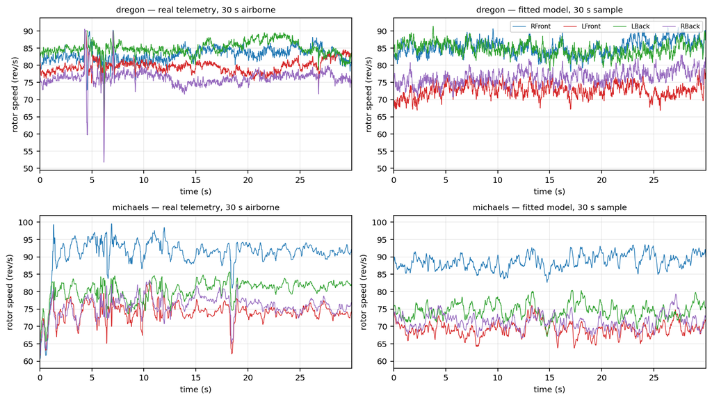

## Real vs sampled trajectories — other rigs

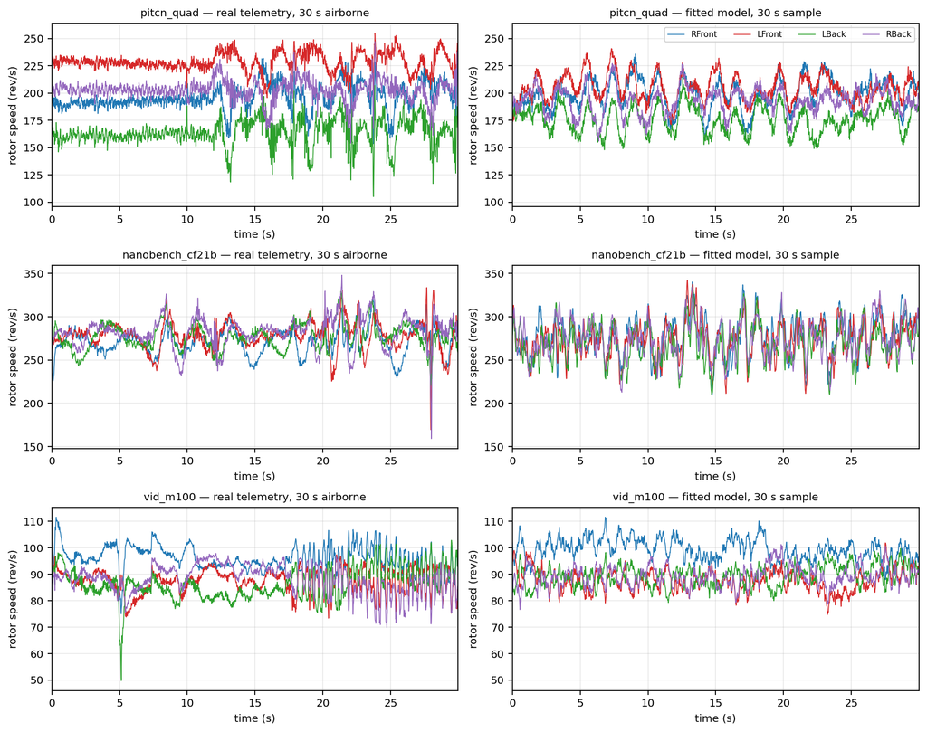

## Trajectories from the rig hyperprior

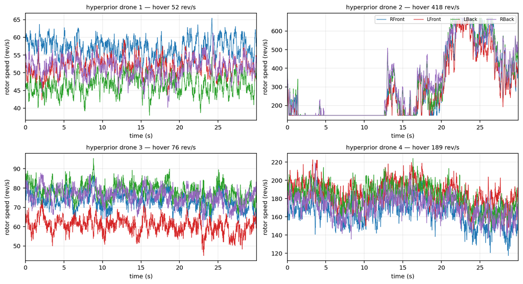

## Noise model

$$x_m(t) = \sum_{r}\sum_{k} A_{mrk}(t)\cos\phi_{mrk}(t) + n_m(t), \qquad
\phi_{mrk} = 2\pi k\!\int_0^t\! f_r + k\theta_r(t) + \psi_{rk}(t) + \alpha_{mrk}$$

$$d\nu_r = -\lambda \nu_r dt + \sqrt{2\lambda}\sigma_\nu dW_r,\quad d\theta_r = \nu_r dt,\qquad
V_\theta(\tau) = 2\sigma_\nu^2\!\left[\tfrac{|\tau|}{\lambda} - \tfrac{1-e^{-\lambda|\tau|}}{\lambda^2}\right]$$

$$\operatorname{Var}[\Delta\psi_{rk}] = 4\pi\gamma_{rk}|\tau| \;\Rightarrow\; R_{rk}(\tau) = \exp\!\left[-\tfrac{k^2}{2}V_\theta(\tau) - 2\pi\gamma_{rk}|\tau|\right]$$

$$A_{mrk}(t) = \sqrt{2P_{rk}}\left(\tfrac{f_r(t)}{f_{\mathrm{ref}}}\right)^{a/2} 10^{(g_{mr}-\bar g)/20} 10^{(G_m - \bar G)/20}, \qquad P_{rk} = 10^{p_{rk}/10}$$

$$S_m(f,t) = 10^{h_m/10}\Big[\tfrac1R\sum_r\big(\tfrac{f_r(t)}{f_{\mathrm{ref}}}\big)^{b} + s\Big]\,
10^{\left(\mu_F + \sum_{j=1}^{14} B_j(f)\sigma_B (Lz)_j + t_F\log_2(f/f_t)\right)/10}$$

Regimes (Michael’s): standby and cruise fits composed on the carrier; the blend weight follows $f_r(t)$.

## Noise model — parameters

| symbol | meaning | shape | prior |
| --- | --- | --- | --- |
| $\sigma_\nu$ | shaft OU speed-error sd (rad/s) | per rotor | bench LN(0.3, 0.7); flight LN(0.3, 0.5) |
| $\lambda$ | shaft OU rate (s$^{-1}$) | per rotor | LN(2, 1.0) on the bench; pinned in flight |
| $\gamma_{rk}$ | Lorentzian half-width of line $(r,k)$ (Hz) | rotor × order | LN($0.01k$ Hz, 1.0), $\gamma \ge 0$ |
| $p_{rk}$ | line power of order $k$ (dB) — the comb profile | rotor × order | N(measured, 10) if SNR ≥ 2 dB, else N($\mu_F-15$, 8) |
| $c$ | level of a transplanted comb (dB) | 1 | N(0, 20) |
| $a$ | comb speed exponent | 1 | N(2, 1); pinned at 2 on a short span |
| $b$ | floor speed exponent | 1 | LN(2, 0.5); same span pin |
| $s$ | static fraction of the floor | 1 | LN($2.5\times10^{-3}$, 1.0) |
| $\mu_F$ | floor level (dB) | 1 | N(measured band median, 10) |
| $z$ | GP control points of the floor shape | 14 | N(0, 1) each |
| $t_F$ | floor tilt (dB/octave) | 1 | N(0, 5) |
| $g_{mr}$, $h_m$, $G_m$ | per-mic line / floor / overall gain (dB) | mic × rotor, mic, mic | N(0, 6) |
| $f_r$ | carrier (rev/s) | per rotor | given: window-refined or telemetry label |

## Noise data

| recording set | class | rotors / mics | duration | role in the fit |
| --- | --- | --- | --- | --- |
| DREGON single-motor bench, 50–90 % | bench | 1 / 8 | 12–34 s per window | identifies $\sigma_\nu$, $\lambda$, $\gamma_{rk}$ |
| DREGON `motor_allMotors_70` bench | bench | 4 / 8 | ~30 s | four-rotor control |
| DREGON room 2: free flight, hover, rectangle, spinning | flight | 4 / 8 | 4 s frames, pooled | floor and flight profile (R5 fit) |
| Michael’s FLY125 cruise | flight | 4 / 1 | 4 s frames, pooled | cruise comb and floor (R3 fit) |
| Michael’s FLY125 standby | flight | 4 / 1 | 4 s frames, pooled | standby regime of the same rig |

Flight supports: periodic Hann, $N = 2048$, hop 512 at 16 kHz. Fit band 30 Hz – 7900 Hz.

## Real vs sampled noise, on the same label

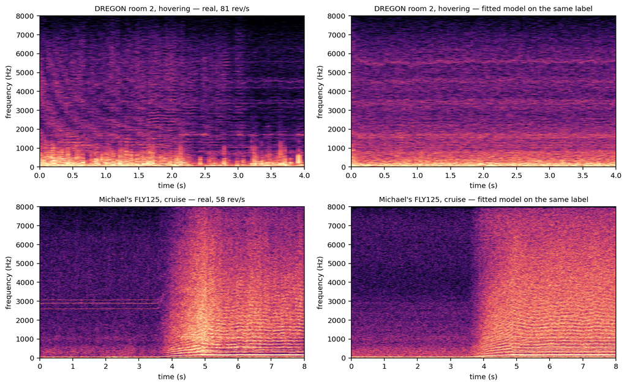

## Hard-bank noise (noise-fit path × trajectory hyperprior) used for hard training

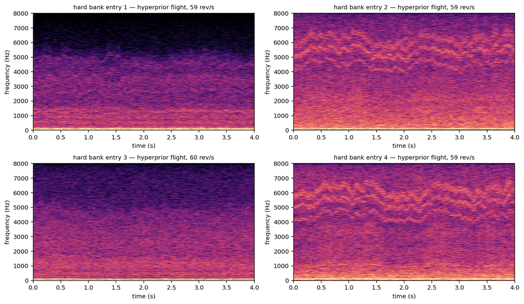

## Results — regressor (SCv2)

rev/s MAE on the real validation split

| arm | stream | real_overall | zero | standby | ramp | cruise |
| --- | --- | --- | --- | --- | --- | --- |
| `real_r4_scv2_unified` | real ref | **2.99** | 2.44 | 3.20 | 8.17 | 2.95 |
| `nv2_easy_scv2` | synth | 7.94 | 10.64 | 11.05 | 11.12 | 6.87 |
| `nv2_hard_scv2` | synth | 7.06 | 1.25 | 6.16 | 15.81 | 7.76 |
| `nv2_mixed_scv2` | mixed | 2.53 | 1.78 | 2.25 | 7.00 | 2.49 |
| `nv2_easy_ft_scv2` | easy→real | 2.73 | 2.23 | 2.36 | 8.16 | 2.60 |
| `nv2_hard_ft_scv2` | hard→real | **2.23** | 0.93 | 1.44 | 6.71 | 2.35 |

`real_overall` = `val/real_r3` at the selected checkpoint. Regime columns: per-frame PIT MAE, 8 mics, frame shares zero 13 % / standby 12 % / ramp 4 % / cruise 72 %; pooled over DREGON and Michael’s.

## Results — salience (HPPNet-L2)

rev/s MAE on the real validation split

| arm | stream | real_overall | zero | standby | ramp | cruise |
| --- | --- | --- | --- | --- | --- | --- |
| `hppnet_l2_r2_s0` | real ref | **2.27** | 1.05 | 3.11 | 12.51 | 1.74 |
| `nv2_easy_hppnet_l2` | synth | 6.46 | 3.58 | 5.04 | 26.50 | 6.14 |
| `nv2_hard_hppnet_l2` | synth | 6.47 | 1.63 | 4.25 | 30.07 | 6.44 |
| `nv2_mixed_hppnet_l2` | mixed | 2.25 | 0.29 | 2.28 | 9.09 | 2.23 |
| `nv2_easy_ft_hppnet_l2` | easy→real | **2.11** | 1.50 | 2.84 | 8.25 | 1.77 |
| `nv2_hard_ft_hppnet_l2` * | hard→real | 4.38 | 20.91 | 2.83 | 9.50 | 1.51 |

Same columns and same selection rule as the regressor slide.

* `nv2_hard_ft_hppnet_l2`: the saved checkpoint is round 4, at 4.38. The run’s raw score reached 1.81 at round 1, but the 5-round median selected round 4, so that checkpoint was never saved — this arm’s real result is unmeasured.

## Conclusions

- We have a probabilistic generative model of drone ego-noise — not deep, built on Gaussian processes — that is fitted to real data points, both for the drone **trajectories** and for the audio those trajectories produce.
- The model is fitted on a small amount of real data from several drones, and the resulting posterior over model parameters lets us sample **unseen** drones.
- Models trained only on synthetic data obtained this way still produce meaningful predictions on real data.
- Models trained on **both** real and synthetic data reach **better overall performance** than models trained on real data only.